# Andropogoneae Species

Michelle C. Stitzer

2024-12-19

# *Schizachyrium microstachyum*

Assembly is haploid, and the genome is diploid. It has a haploid genome size of 900 Mb, and has 10 haploid chromosomes.

### Species herbarium records

Herbarium records of *Schizachyrium microstachyum* from [AuBuchon-Elder et al 2022](https://nph.onlinelibrary.wiley.com/doi/full/10.1002/ppp3.10355) are plotted with black points, The sampled individual this genome was generated from is shown in a colored point. The green background shows the biogeographic ranges of all Andropogoneae species in [AuBuchon-Elder et al 2022](https://nph.onlinelibrary.wiley.com/doi/full/10.1002/ppp3.10355).

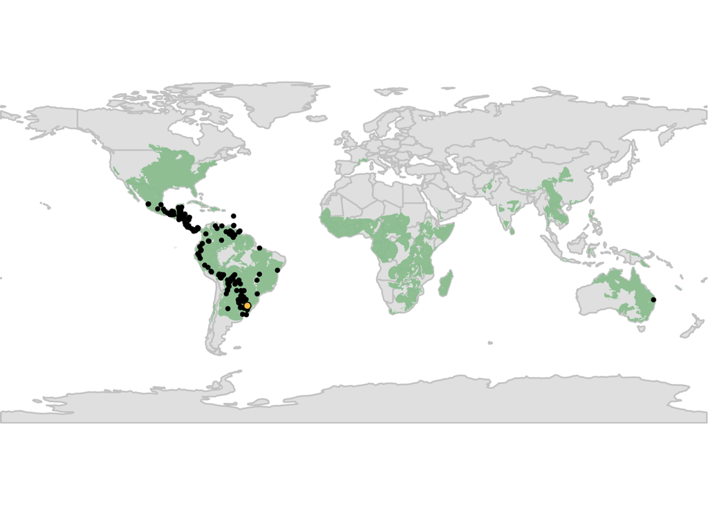

### Highlighted Figure 1

Figure 1 from the main text, with *Schizachyrium microstachyum* highlighted with colored points.

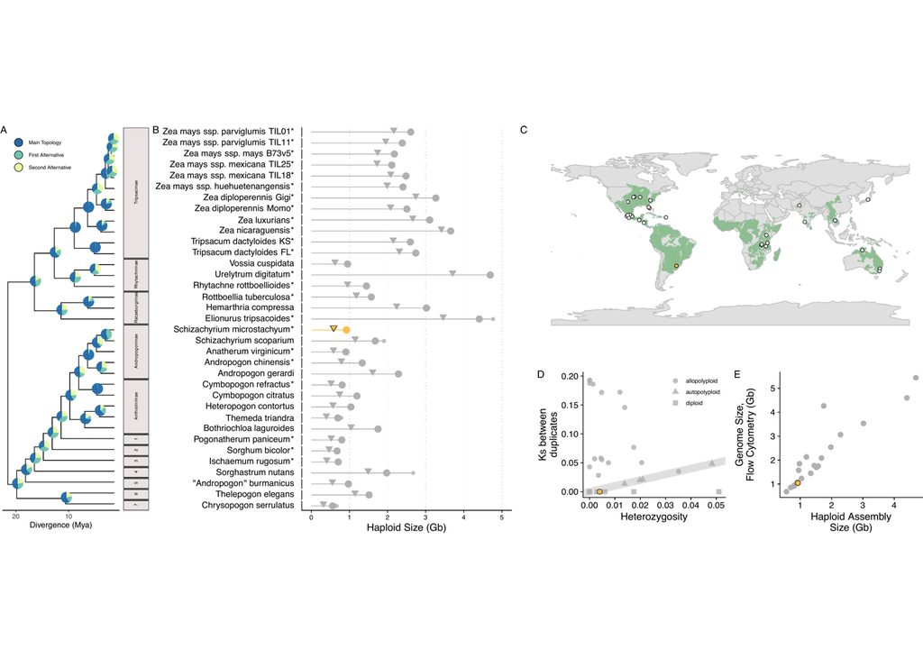

### Highlighted Figure 2

Figure 2 from the main text, with *Schizachyrium microstachyum* highlighted with colored points.

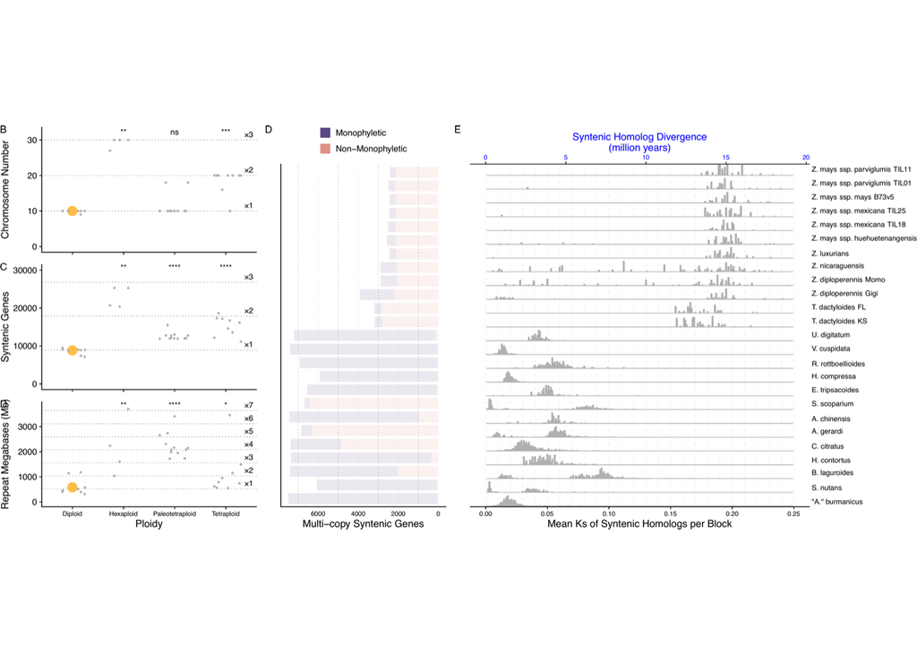

### Dotplot of *Schizachyrium microstachyum* vs. *Paspalum vaginatum*.

Like dotplots shown in Figure 3 of the main text, this shows syntenic blocks in *Schizachyrium microstachyum* along the y-axis, vs *P. vaginatum* on the x-axis. As Schizachyrium microstachyum is a diploid with a haploid, assembly, we expect 1 paths for any x-axis position.

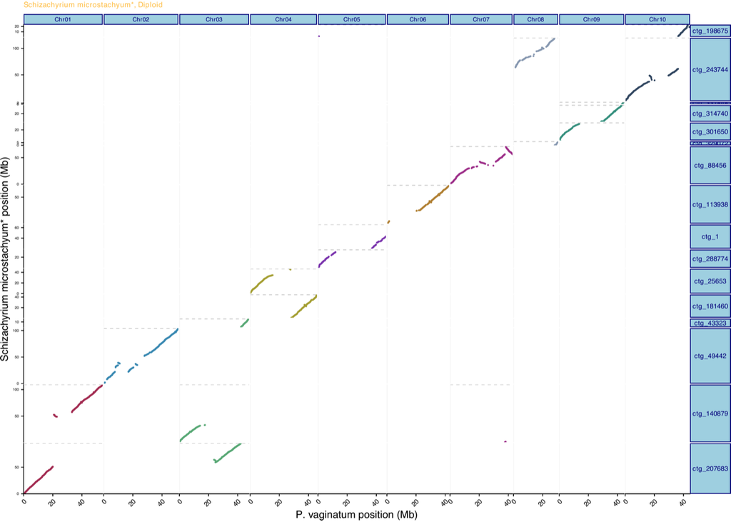